# Microglia Gene Expression Analysis: batch and sex covariates

Raquel Garza

## Overview

This notebook is a repetition of gene_DEA_GSEA.Rmd to verify that the results hold when adjusting for batch and sex effects in the design formula of the differential expression analyses.

- trusTEr output files with gene counts per cluster/region
- Sample metadata: ASAP_samplesheet.xlsx

### Notes

- Only expressed genes (row sums > 0) are tested.

## Setup: Load libraries and helper functions

Load all required libraries and custom DEA functions

```r
library(DESeq2)
library(data.table)
library(ggpubr)
```

```r
library(ggplot2)
library(tidyverse)
library(openxlsx)
library(pheatmap)
library(clusterProfiler)
library(org.Hs.eg.db)
library(EnhancedVolcano)
source("TE_DEA_functions.R")
```

## Characterize PD effect per cluster

Differential expression analyses for PD vs Control pseudobulks (adjusting for batch and sex) for each region in microglia (cluster 4). Save results (one excel with region per sheet).

```r
samplesheet <- read.xlsx("/Volumes/MyPassport/ASAP/code/ASAP_PMDBS_snRNAseq/original/ASAP_samplesheet.xlsx")
gene_dds_list <- list()
gene_exp_list <- list()
gene_res_list <- list()
gene_res_list_df <- list()
regions <- c("SN", "PUT", "AMY", "PFC")
cluster <- "4" # Microglia cluster
gene_dds_list[[cluster]] <- list()
gene_exp_list[[cluster]] <- list()
gene_res_list[[cluster]] <- list()
gene_res_list_df[[cluster]] <- list()
for(region in regions){
  print(cluster)
  print(region)
  gene_counts <- list()
  gene_counts[[region]] <- fread(paste("~/inbox/ASAP/trusTEr_output_vs2/", region,"/gene_counts_", region,"_",cluster,".csv", sep=""), sep = ",", data.table = F)
  rownames(gene_counts[[region]]) <- gene_counts[[region]]$Geneid

  samplesheet_list <- split(samplesheet, f = samplesheet$Region)

  rownames(samplesheet_list[[region]]) <- samplesheet_list[[region]]$Sample
  samples_cluster <- paste(rownames(samplesheet_list[[region]]), cluster, sep="_")
  samples_cluster <- samples_cluster[which(samples_cluster %in% colnames(gene_counts[[region]]))]
  rownames(samplesheet_list[[region]]) <- paste(rownames(samplesheet_list[[region]]), cluster, sep="_")
  rownames(gene_counts[[region]]) <- gene_counts[[region]]$Geneid

  expressed_genes <- rownames(gene_counts[[region]])[which(rowSums(gene_counts[[region]][,samples_cluster]) > 0)]
  gene_dds_list[[cluster]][[region]] <- DESeqDataSetFromMatrix((gene_counts[[region]][expressed_genes,samples_cluster]+1), samplesheet_list[[region]][samples_cluster,], design =  ~ Seqnum + Sex + Dx) # Covariates with batch and sex
  gene_dds_list[[cluster]][[region]]$Dx <- relevel(gene_dds_list[[cluster]][[region]]$Dx, "Ctl")
  gene_dds_list[[cluster]][[region]] <- DESeq(gene_dds_list[[cluster]][[region]])
  gene_res_list[[cluster]][[region]] <- results(gene_dds_list[[cluster]][[region]], )
  gene_res_list_df[[cluster]][[region]] <- as.data.frame(gene_res_list[[cluster]][[region]])
  gene_res_list_df[[cluster]][[region]]$gene_id <- rownames(gene_res_list_df[[cluster]][[region]])
  print(names(gene_res_list_df[[cluster]]))
}
```

```
## [1] "4"
## [1] "SN"
```

```
## -- note: fitType='parametric', but the dispersion trend was not well captured by the
##    function: y = a/x + b, and a local regression fit was automatically substituted.
##    specify fitType='local' or 'mean' to avoid this message next time.
```

```
## [1] "SN"
## [1] "4"
## [1] "PUT"
```

```
## -- note: fitType='parametric', but the dispersion trend was not well captured by the
##    function: y = a/x + b, and a local regression fit was automatically substituted.
##    specify fitType='local' or 'mean' to avoid this message next time.
```

```
## -- replacing outliers and refitting for 323 genes
## -- DESeq argument 'minReplicatesForReplace' = 7
## -- original counts are preserved in counts(dds)
```

```
## [1] "SN"  "PUT"
## [1] "4"
## [1] "AMY"
```

```
## -- note: fitType='parametric', but the dispersion trend was not well captured by the
##    function: y = a/x + b, and a local regression fit was automatically substituted.
##    specify fitType='local' or 'mean' to avoid this message next time.
```

```
## [1] "SN"  "PUT" "AMY"
## [1] "4"
## [1] "PFC"
```

```
## -- note: fitType='parametric', but the dispersion trend was not well captured by the
##    function: y = a/x + b, and a local regression fit was automatically substituted.
##    specify fitType='local' or 'mean' to avoid this message next time.
```

```
## [1] "SN"  "PUT" "AMY" "PFC"
```

```r
openxlsx::write.xlsx(gene_res_list_df[[cluster]], paste("/Volumes/MyPassport/ASAP/data/ASAP_PMDBS_snRNAseq/results/tables/gene_cluster_", cluster, "_PD_DEA_batch_sex_snRNAseq_res.xlsx", sep=""))
```

## Some helper functions for Gene Set Enrichment Analyses

```r
set.seed(10)
gse_dotplot <- function(df){
  genelist <- df[which(!is.na(df$log2FoldChange)),c("log2FoldChange", "gene_id"), drop=F]
  genelist <- genelist[order(genelist$log2FoldChange, decreasing = T),]

  genelist_FC <- genelist$log2FoldChange
  names(genelist_FC) <- genelist$gene_id
  gse <- gseGO(geneList=genelist_FC,
               ont ="ALL",
               keyType = "SYMBOL",
               minGSSize = 3,
               maxGSSize = 800,
               seed = T,
               pvalueCutoff = 0.05,
               verbose = TRUE,
               OrgDb = org.Hs.eg.db,
               pAdjustMethod = "BH")
  return(gse)
}

gse_pretty_dotplot <- function(gse, topn = 10, terms = NA){
  gse <- gse@result
  # gse <- gse[which(gse$ONTOLOGY == "BP"),]
  gse$sign <- ifelse(gse$enrichmentScore > 0, "Activated", "Supressed")
  gse$num_genes <- sapply(str_split(gse$core_enrichment, "/"), length)
  gse$gene_ratio <- gse$num_genes / gse$setSize
  gse$Description <- factor(gse$Description, levels = gse[order(gse$gene_ratio), "Description"])

  if(!all(is.na(terms))){
    gse <- gse %>%
      drop_na() %>%
      filter(ID %in% terms)
  }else{
    gse <- gse[order(gse$NES, -log10(gse$p.adjust), decreasing = T),]
  }
  gse %>%
      drop_na() %>%
      ggplot(aes(x=Description, y=gene_ratio, size = num_genes, fill = p.adjust)) + geom_point(shape=21, colour="lightgrey") + facet_wrap(.~sign) + coord_flip() + theme_pubr(legend = "right", border = T) + labs(x="", fill="Padj", y = "Gene ratio", size = "Num genes") + scale_fill_gradientn(colors = c("firebrick1", "gray94")) + scale_size_continuous(range = c(2,8)) + theme(axis.text.y = element_text(size=10), strip.text.x = element_text(size = 10),axis.text.x = element_text(size=10),legend.text = element_text(size=10),legend.title = element_text(size=10))
}
```

## Gene Set Enrichment Analyses (GSEA)

- Test whether there is enrichment of GO-terms within the DEA results (log2FC based).
- Save results to excel

```r
gse_list <- list()
gse_list_df <- list()
gse_plot_list <- list()
gse_list[[cluster]] <- list()
gse_list_df[[cluster]] <- list()
gse_plot_list[[cluster]] <- list()
for(region in regions){
  print(cluster)
  print(region)
  gse_list[[cluster]][[region]] <- gse_dotplot(df = gene_res_list_df[[cluster]][[region]])
  gse_list_df[[cluster]][[region]] <- gse_list[[cluster]][[region]]@result
  if(!is.null(gse_plot_list[[cluster]][[region]])){
  # gse_plot_list[[cluster]][[region]] <- gse_pretty_dotplot(gse = gse_list[[cluster]][[region]], topn = 30) + ggtitle(paste(region, cluster, sep=" cluster: "))
  }
}
```

```
## [1] "4"
## [1] "SN"
```

```
## using 'fgsea' for GSEA analysis, please cite Korotkevich et al (2019).
```

```
## preparing geneSet collections...
```

```
## GSEA analysis...
```

```
## leading edge analysis...
```

```
## done...
```

```
## [1] "4"
## [1] "PUT"
```

```
## using 'fgsea' for GSEA analysis, please cite Korotkevich et al (2019).
```

```
## preparing geneSet collections...
```

```
## GSEA analysis...
```

```
## leading edge analysis...
```

```
## done...
```

```
## [1] "4"
## [1] "AMY"
```

```
## using 'fgsea' for GSEA analysis, please cite Korotkevich et al (2019).
```

```
## preparing geneSet collections...
```

```
## GSEA analysis...
```

```
## leading edge analysis...
```

```
## done...
```

```
## [1] "4"
## [1] "PFC"
```

```
## using 'fgsea' for GSEA analysis, please cite Korotkevich et al (2019).
```

```
## preparing geneSet collections...
```

```
## GSEA analysis...
```

```
## leading edge analysis...
```

```
## done...
```

```r
if(length(gse_list_df[[cluster]]) > 0){
openxlsx::write.xlsx(gse_list_df[[cluster]], paste("/Volumes/MyPassport/ASAP/data/ASAP_PMDBS_snRNAseq/results/tables/gse_cluster", cluster, "PD_GSEA_batch_sex_snRNAseq_res.xlsx", sep="_"))
}
```

## IFN and viral related terms in microglia

[figure not shown]

```r
cluster = "4"
region = "SN"
ifn_viral_related_go <- gse_list_df[[cluster]][[region]][which(grepl("interferon|vir", gse_list_df[[cluster]][[region]]$Description)), "ID"]
gse_pretty_dotplot(gse = gse_list[[cluster]][[region]], topn = 10, terms = c(ifn_viral_related_go)) + ggtitle(paste(region, cluster, sep=" cluster: "))
```

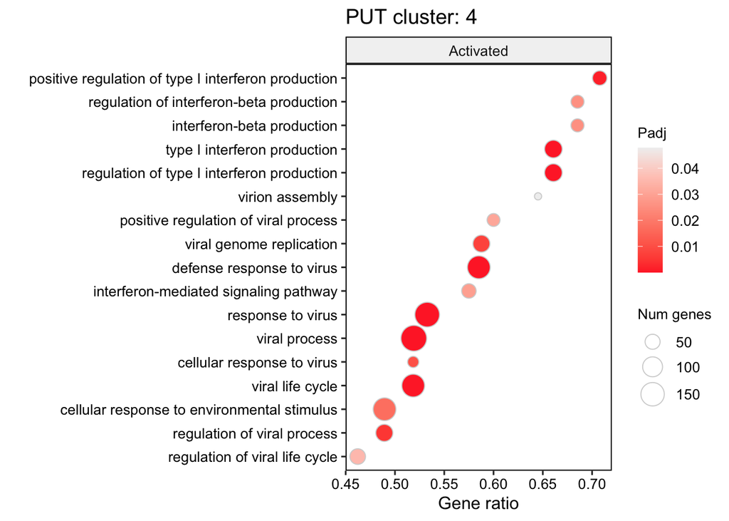

```r
region = "PUT"
ifn_viral_related_go <- gse_list_df[[cluster]][[region]][which(grepl("interferon|vir", gse_list_df[[cluster]][[region]]$Description)), "ID"]
gse_pretty_dotplot(gse = gse_list[[cluster]][[region]], topn = 10, terms = c(ifn_viral_related_go)) + ggtitle(paste(region, cluster, sep=" cluster: "))
```

[figure not shown]

```r
region = "AMY"
ifn_viral_related_go <- gse_list_df[[cluster]][[region]][which(grepl("interferon|vir", gse_list_df[[cluster]][[region]]$Description)), "ID"]
gse_pretty_dotplot(gse = gse_list[[cluster]][[region]], topn = 10, terms = c(ifn_viral_related_go)) + ggtitle(paste(region, cluster, sep=" cluster: "))
```

```r
region = "PFC"
ifn_viral_related_go <- gse_list_df[[cluster]][[region]][which(grepl("interferon|vir", gse_list_df[[cluster]][[region]]$Description)), "ID"]
ifn_viral_related_go
```

```
## character(0)
```

## IFN related genes avg log2FC heatmaps

IFN related genes that were up in PD SN microglia

[figure not shown]

```r
gene_res_list_df$`4`$SN$region <- "SN"
gene_res_list_df$`4`$PUT$region <- "PUT"
gene_res_list_df$`4`$PFC$region <- "PFC"
gene_res_list_df$`4`$AMY$region <- "AMY"

ifn_related_go <- gse_list_df[["4"]][["SN"]][which(grepl("interferon", gse_list_df[["4"]][["SN"]]$Description)), "Description"]
tmp <- sapply(sapply(gse_list_df[["4"]][["SN"]][which(gse_list_df[["4"]][["SN"]]$Description %in% ifn_related_go), "core_enrichment"], str_split, "/"), unlist)
names(tmp) <- NULL
tmp <- unique(unlist(tmp))

tmp_res <- rbind(gene_res_list_df$`4`$SN[tmp,],
gene_res_list_df$`4`$PUT[tmp,],
gene_res_list_df$`4`$PFC[tmp,],
gene_res_list_df$`4`$AMY[tmp,])

tmp_res <- unique(tmp_res)

tmp_heatmap_log2FC <- reshape2::dcast(tmp_res, gene_id~region, value.var = "log2FoldChange")
rownames(tmp_heatmap_log2FC) <- tmp_heatmap_log2FC$gene_id
tmp_heatmap_pvalue <- reshape2::dcast(tmp_res, gene_id~region, value.var = "pvalue")
tmp_heatmap_pvalue[is.na(tmp_heatmap_pvalue)] <- 1
rownames(tmp_heatmap_pvalue) <- tmp_heatmap_pvalue$gene_id
tmp_heatmap_pvalue <- tmp_heatmap_pvalue[,-1]
tmp_heatmap_pvalue <- ifelse(tmp_heatmap_pvalue > 0.05, "", ifelse(tmp_heatmap_pvalue < 0.001, "***", ifelse(tmp_heatmap_pvalue < 0.01, "**", "*")))

bk_neg <- seq(-3,0, length.out=50)
bk_pos <- seq(0,3, length.out=50)
bk <- c(bk_neg, bk_pos)
bk <- unique(bk)
color_pos <- colorRampPalette(c("white", "red"))(50)
color_neg <- colorRampPalette(c("blue", "white"))(50)
tmp_heatmap_log2FC[is.na(tmp_heatmap_log2FC)] <- 0

pheatmap::pheatmap(tmp_heatmap_log2FC[,-1], breaks = bk, color = c(color_neg, color_pos), cluster_cols = F, main = "Core enrichment of enriched IFN-related\nGO terms in SN microglia", show_rownames = T, border_color = F, display_numbers = tmp_heatmap_pvalue)
```

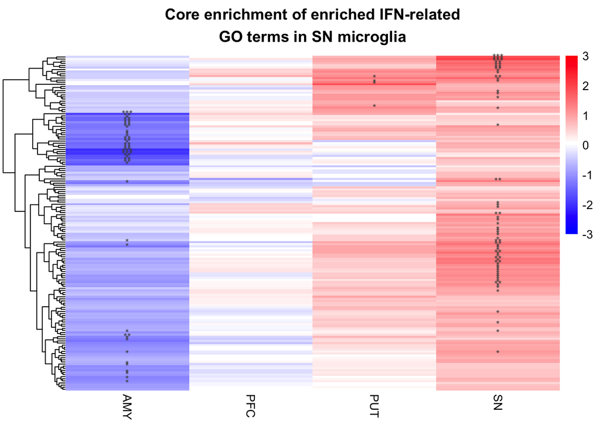

```r
pheatmap::pheatmap(tmp_heatmap_log2FC[,-1], breaks = bk, color = c(color_neg, color_pos), cluster_cols = F, main = "Core enrichment of enriched IFN-related\nGO terms in SN microglia", show_rownames = F, border_color = F, display_numbers = tmp_heatmap_pvalue)
```